# Presentacion Proyecto Ciencia de datos

July 2024

## Contenido

1. Introducción
2. Objetivo 1
3. Objetivo 2
4. Objetivo 3
5. Conclusiones

## Introducción

- **Objetivo general**: analizar y comprender tendencias, la prevalencia y los factores asociados con la discriminación en diversos contextos y grupos demográficos.
  1. Identificar tendencias de discriminación utilizando gráficos de series temporales
  2. Identificar la tasa de discriminación de las CA de España
  3. Explorar la relación entre haber tenido un trabajo pagado y sentirse discriminado.

## Objetivo 1: tendencias de discriminación

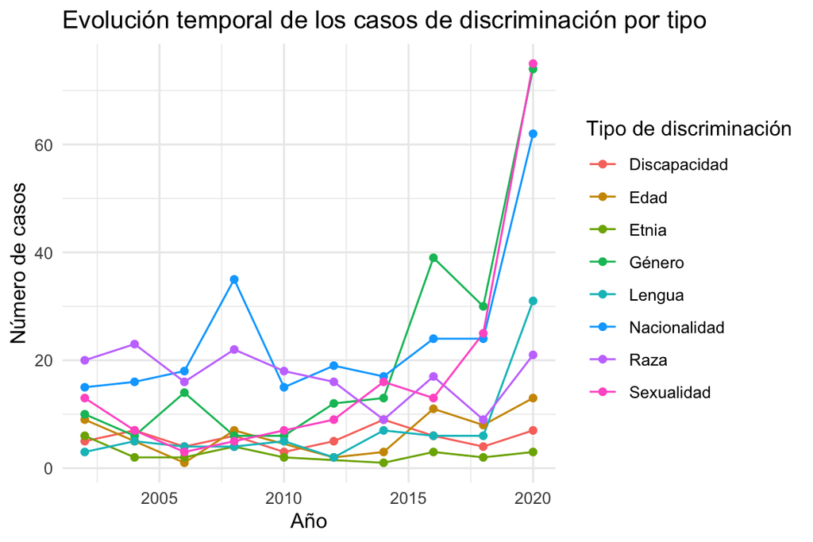

## Objetivo 2: Tasa de discriminación

| region | casos | poblacion | tasa_discriminacion |
| --- | --- | --- | --- |
| Galicia | 47 | 2701743 | 1.7396177 |
| Asturias | 9 | 1006193 | 0.8944606 |
| Cantabria | 15 | 583904 | 2.5689154 |
| País Vasco | 42 | 2188017 | 1.9195463 |
| Foral de Navarra | 11 | 661203 | 1.6636343 |
| La Rioja | 7 | 319914 | 2.1880880 |
| Aragón | 28 | 1320586 | 2.1202708 |
| Madrid | 138 | 6714142 | 2.0553631 |
| Castilla y León | 40 | 2394918 | 1.6702033 |
| Castilla-La Mancha | 17 | 2046107 | 0.8308461 |

## Objetivo 2: Tasa de discriminación II

| region | casos | poblacion | tasa_discriminacion |
| --- | --- | --- | --- |
| Extremadura | 11 | 1065424 | 1.0324528 |
| Cataluña | 148 | 7739758 | 1.9122045 |
| Valenciana | 71 | 5057353 | 1.4038965 |
| Islas Baleares | 15 | 1172540 | 1.2792741 |
| Andalucía | 81 | 8472403 | 0.9560452 |
| Murcia | 12 | 1511251 | 0.7940441 |
| Ceuta | 1 | 84777 | 1.1795652 |
| Melilla | 1 | 86384 | 1.1576218 |
| Canary Is. | 15 | 2252465 | 0.6659371 |

## Objetivo 2: Tasa de discriminación III

1. **Tasas más Altas**
   - **Cantabria**: 2.57 casos por cada 100,000 habitantes
   - **La Rioja**: 2.19 casos
   - **Aragón**: 2.12 casos
2. **Casos Absolutos**
   - **Cataluña**: 148 casos reportados
   - **Comunidad de Madrid**: 138 casos
   - **Andalucía**: 81 casos
3. **Tasas más Bajas**
   - **Canarias**: 0.67 casos por cada 100,000 habitantes
   - **Castilla-La Mancha**: 0.83 casos
   - **Región de Murcia**: 0.79 casos

## Objetivo 3: Discriminación y variables sociográficas

| pdjobev | discriminacion_total | count | percentage |
| --- | --- | --- | --- |
| Sí | No | 6050 | 95.606827 |
| Sí | Sí | 278 | 4.393173 |
| No | No | 2738 | 94.871795 |
| No | Sí | 148 | 5.128205 |

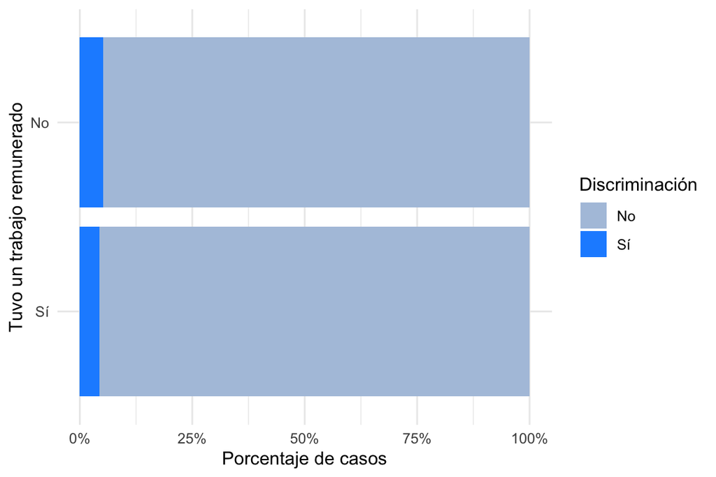

## Objetivo 3: Discriminación y Variables Sociográficas II

1. **Participantes con Trabajo Pagado (Sí)**
   - **No Discriminados**: 95.61% (6050 casos)
   - **Discriminados**: 4.39% (278 casos)
   - La mayoría de las personas con experiencia laboral remunerada no ha enfrentado discriminación, aunque hay una minoría significativa que sí la ha sufrido.
2. **Participantes sin Trabajo Pagado (No)**
   - **No Discriminados**: 94.87% (2738 casos)
   - **Discriminados**: 5.13% (148 casos)
   - Aunque la proporción de discriminación es ligeramente mayor en este grupo, la mayoría sigue sin haber enfrentado discriminación.
3. **Conclusión General**
   - Haber tenido un trabajo pagado no parece estar fuertemente asociado con la experiencia de discriminación.
   - Hay una ligera variación en las tasas de discriminación entre los dos grupos.